# Reproducible Research: Peer Assessment 1

Mikhail Tarasov

Friday, April 17, 2015

```r
#opts_chunk$set(echo = TRUE)
Sys.setlocale("LC_TIME", "English")
```

```
## [1] "English_United States.1252"
```

## Loading and preprocessing the data

Unzip *activity.zip* into sub-folder *data*. Then read the data file and load data into *activity* data set. Convert column *date* into *Date* data type.

```r
if (!file.exists("data\activity.csv"))
{
    if (file.exists("activity.zip"))
    {
        unzip("activity.zip", exdir = "data")
    }
    else
    {
        stop("Can't find zip file (activity.zip).")
    }
}

activity <- read.csv("data/activity.csv", stringsAsFactors = FALSE)
activity$date <- as.Date(activity$date, format = "%Y-%m-%d")
summary(activity)
```

```
##      steps             date               interval
##  Min.   :  0.00   Min.   :2012-10-01   Min.   :   0.0
##  1st Qu.:  0.00   1st Qu.:2012-10-16   1st Qu.: 588.8
##  Median :  0.00   Median :2012-10-31   Median :1177.5
##  Mean   : 37.38   Mean   :2012-10-31   Mean   :1177.5
##  3rd Qu.: 12.00   3rd Qu.:2012-11-15   3rd Qu.:1766.2
##  Max.   :806.00   Max.   :2012-11-30   Max.   :2355.0
##  NA's   :2304
```

I will use **dplyr** package for data manipulation.

```r
library(dplyr)
```

## What is mean total number of steps taken per day?

Missing values are ignored. Chain operators are intensively used here.

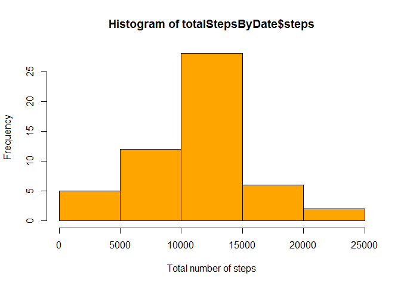

```r
totalStepsByDate <-
    activity %>%
    filter(is.na(steps)==FALSE) %>%
    group_by(date) %>%
    summarise(sum(steps))
names(totalStepsByDate)[2]<-"steps"
hist(x = totalStepsByDate$steps, xlab = "Total number of steps", col = "orange")
```

```r
meanStepsByDate <-
    activity %>%
    filter(is.na(steps)==FALSE) %>%
    group_by(date) %>%
    summarise(mean(steps))
summary(meanStepsByDate)
```

```
##       date             mean(steps)
##  Min.   :2012-10-02   Min.   : 0.1424
##  1st Qu.:2012-10-16   1st Qu.:30.6979
##  Median :2012-10-29   Median :37.3785
##  Mean   :2012-10-30   Mean   :37.3826
##  3rd Qu.:2012-11-16   3rd Qu.:46.1597
##  Max.   :2012-11-29   Max.   :73.5903
```

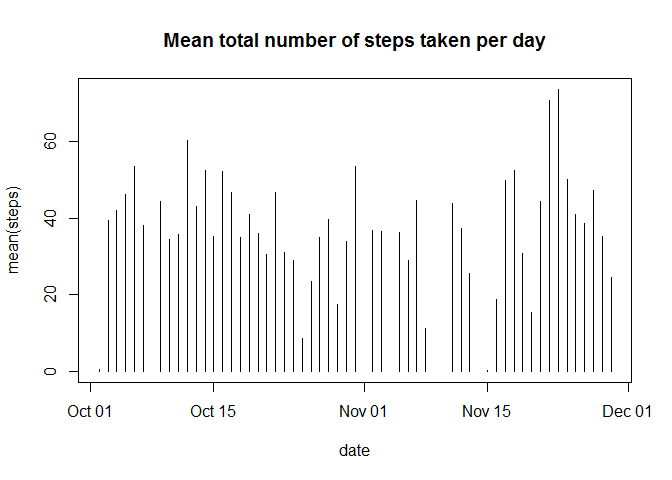

```r
plot(meanStepsByDate, type = "h", main = "Mean total number of steps taken per day")
```

```r
medianSteps<-as.character(round(median(totalStepsByDate$steps)))
meanSteps <- as.character(round(mean(totalStepsByDate$steps)))
```

The median number of steps is **10765**. The mean number of steps is **10766**.

## What is the average daily activity pattern?

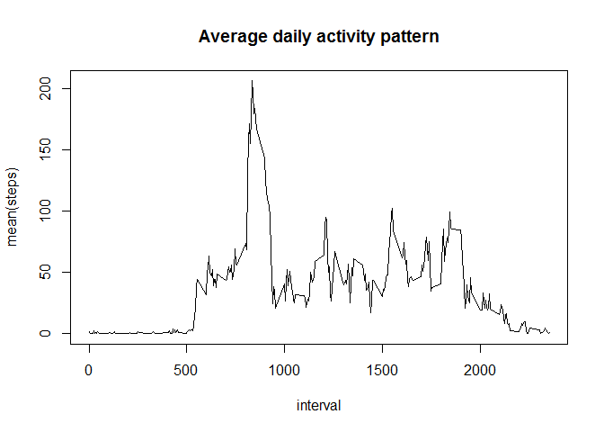

```r
meanStepsByInterval <-
    activity %>%
    filter(is.na(steps)==FALSE) %>%
    group_by(interval) %>%
    summarise(mean(steps))

plot(meanStepsByInterval, type = "l", main = "Average daily activity pattern")
```

```r
names(meanStepsByInterval)[2]<-"mean_steps"
names(meanStepsByDate)[2]<-"mean_steps"
maxInterval <- meanStepsByInterval[which.max(meanStepsByInterval$mean_steps), 1]
maxSteps <- max(meanStepsByInterval$mean_steps)
```

The maximum number of steps is **206.1698113**. This is *835th* interval (which contains the maximum number of steps).

## Imputing missing values

### Counting total number of missing values

```r
naValues <- colSums(is.na(activity))
naCount <- sum(naValues)
naValues
```

```
##    steps     date interval
##     2304        0        0
```

As we can see there are **2304** rows with NA’s and they are in *steps* column only.

### Filling in all of the missing values & creating a new dataset

```r
new_activity <-
    activity %>%
    group_by(interval) %>%
    mutate(steps = ifelse(is.na(steps), as.integer(mean(steps, na.rm =TRUE)), steps))
summary(activity)
```

```
##      steps             date               interval
##  Min.   :  0.00   Min.   :2012-10-01   Min.   :   0.0
##  1st Qu.:  0.00   1st Qu.:2012-10-16   1st Qu.: 588.8
##  Median :  0.00   Median :2012-10-31   Median :1177.5
##  Mean   : 37.38   Mean   :2012-10-31   Mean   :1177.5
##  3rd Qu.: 12.00   3rd Qu.:2012-11-15   3rd Qu.:1766.2
##  Max.   :806.00   Max.   :2012-11-30   Max.   :2355.0
##  NA's   :2304
```

```r
summary(new_activity)
```

```
##      steps             date               interval
##  Min.   :  0.00   Min.   :2012-10-01   Min.   :   0.0
##  1st Qu.:  0.00   1st Qu.:2012-10-16   1st Qu.: 588.8
##  Median :  0.00   Median :2012-10-31   Median :1177.5
##  Mean   : 37.33   Mean   :2012-10-31   Mean   :1177.5
##  3rd Qu.: 27.00   3rd Qu.:2012-11-15   3rd Qu.:1766.2
##  Max.   :806.00   Max.   :2012-11-30   Max.   :2355.0
```

```r
newTotalStepsByDate <-
    new_activity %>%
    filter(is.na(steps)==FALSE) %>%
    group_by(date) %>%
    summarise(sum(steps))
names(newTotalStepsByDate)[2]<-"steps"

newMeanStepsByDate <-
    new_activity %>%
    filter(is.na(steps)==FALSE) %>%
    group_by(date) %>%
    summarise(mean(steps))
names(newMeanStepsByDate)[2]<-"mean_steps"
```

### Making a histograms.

There are NO missing values.

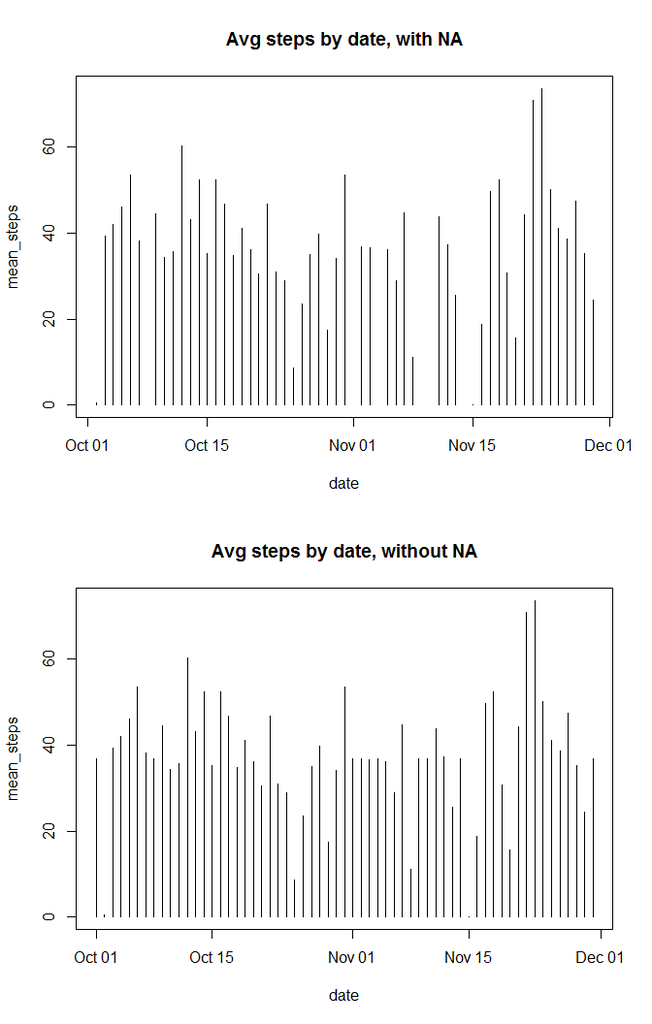

```r
par(mfrow = c(2, 1))
plot(meanStepsByDate, type = "h", main = "Avg steps by date, with NA")
plot(newMeanStepsByDate, type = "h", main = "Avg steps by date, without NA")
```

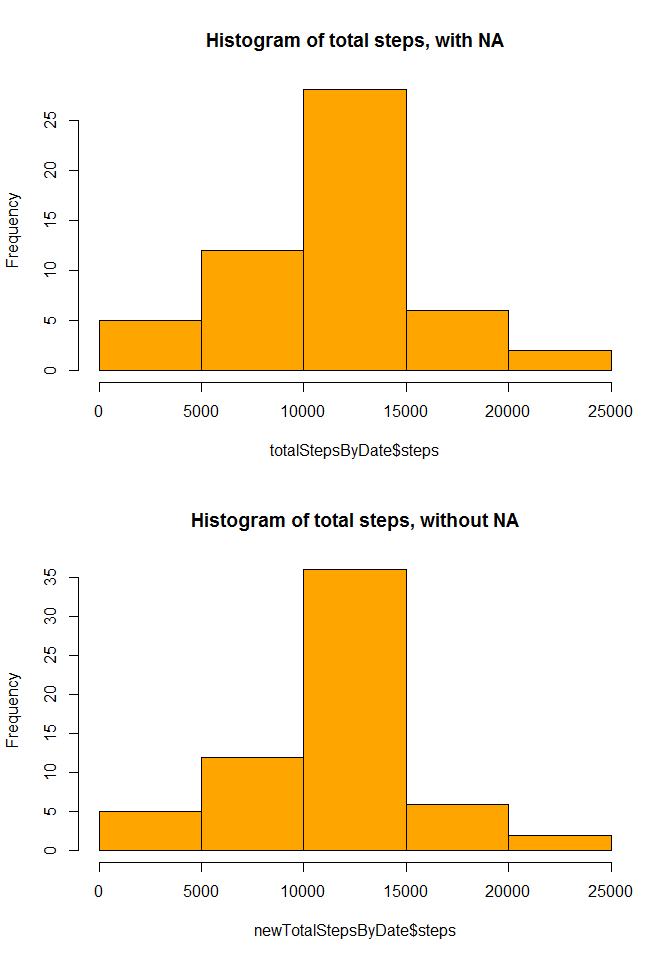

```r
par(mfrow = c(2, 1))
hist(totalStepsByDate$steps, main = "Histogram of total steps, with NA",  col = "orange")
hist(newTotalStepsByDate$steps, main = "Histogram of total steps, without NA",  col = "orange")
```

```r
newMedianSteps<-as.character(round(median(newTotalStepsByDate$steps)))
newMeanSteps <- as.character(round(mean(newTotalStepsByDate$steps)))
```

The median number of steps *without NA* is **10641**. The mean number of steps *without NA* is **10750**.

## Are there differences in activity patterns between weekdays and weekends?

```r
new_activity <- cbind(new_activity, as.factor(ifelse(weekdays(new_activity$date) %in% (c("Monday", "Tuesday", "Wednesday", "Thursday", "Friday")), yes = "weekday", no = "weekend")))
names(new_activity)[4]<-"weekDay_End"
table(new_activity$weekDay_End)
```

```
##
## weekday weekend
##   12960    4608
```

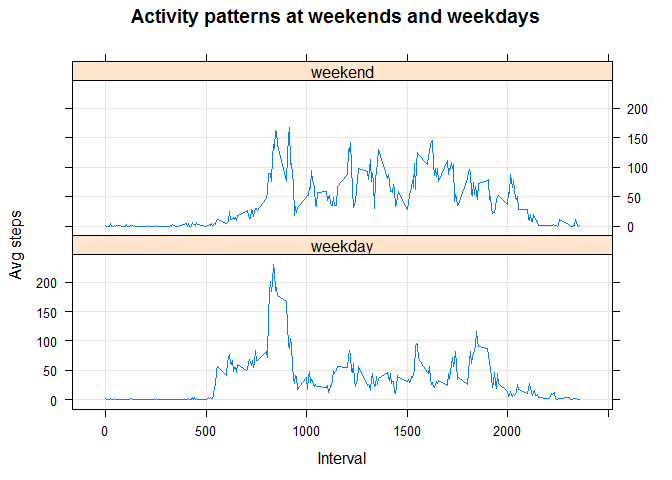

```r
library(lattice)

#Transforming data for the plot
newMeanStepsByInterval <-
    new_activity %>%
    group_by(interval, weekDay_End) %>%
    summarise(mean(steps))
    names(newMeanStepsByInterval)[3]<-"mean_steps"

#Making the panel plot
x <- newMeanStepsByInterval$interval
y <- newMeanStepsByInterval$mean_steps
f <- newMeanStepsByInterval$weekDay_End
g1 <- xyplot(y ~ x | f, xlab ="Interval", ylab = "Avg steps", main = "Activity patterns at weekends and weekdays", layout = c(1, 2), panel = function(x, y, ...) {
  panel.xyplot(x, y, ..., type = "l", grid = TRUE, horizontal = "h")
  })
print(g1)
```

Activity patterns are different. I can see that at the weekends there are much more steps during daytime.